# How Does A Bike Share Navigate Speedy Success

Muhamad Amirul Adham

2024-01-02

## Introduction

Cyclistic: A bike-share program that features more than 5,800 bicycles and 600 docking stations. Cyclistic sets itself apart by also offering reclining bikes, hand tricycles, and cargo bikes, making bike-share more inclusive to people with disabilities and riders who can’t use a standard two-wheeled bike.

The director of marketing believes the company’s future success depends on maximizing the number of annual memberships. Therefore, the team wants to understand how casual riders and annual members use Cyclistic bikes differently. From these insights, the team will design a new marketing strategy to convert casual riders into annual members.

## Objective

How do annual members and casual riders use Cyclistic bikes differently?

Why would casual riders buy Cyclistic annual memberships?

How can Cyclistic use digital media to influence casual riders to become members?

## Data

The latest 12 month data will be collected from [Cyclistic historical trip data](https://divvy-tripdata.s3.amazonaws.com/index.html) for the analysis.

## Analysis

### RStudio

Upload all the 12 separate csv file into RStudio and merge it as a one dataset

```
##            ride_id rideable_type          started_at            ended_at
## 1 65DBD2F447EC51C2 electric_bike 2022-12-05 10:47:18 2022-12-05 10:56:34
## 2 0C201AA7EA0EA1AD  classic_bike 2022-12-18 06:42:33 2022-12-18 07:08:44
## 3 E0B148CCB358A49D electric_bike 2022-12-13 08:47:45 2022-12-13 08:59:51
## 4 54C5775D2B7C9188  classic_bike 2022-12-13 18:50:47 2022-12-13 19:19:48
## 5 A4891F78776D35DF  classic_bike 2022-12-14 16:13:39 2022-12-14 16:27:50
## 6 DB91D9B8DFACA07A electric_bike 2022-12-02 15:24:47 2022-12-02 15:34:14
##           start_station_name start_station_id          end_station_name
## 1 Clifton Ave & Armitage Ave     TA1307000163 Sedgwick St & Webster Ave
## 2     Broadway & Belmont Ave            13277 Sedgwick St & Webster Ave
## 3      Sangamon St & Lake St     TA1306000015    St. Clair St & Erie St
## 4      Shields Ave & 31st St     KA1503000038    Damen Ave & Madison St
## 5  Ashland Ave & Chicago Ave            13247 Damen Ave & Charleston St
## 6        Wabash Ave & 9th St     TA1309000010 Wacker Dr & Washington St
##   end_station_id start_lat start_lng  end_lat   end_lng member_casual
## 1          13191  41.91824 -87.65711 41.92217 -87.63889        member
## 2          13191  41.94011 -87.64545 41.92217 -87.63889        casual
## 3          13016  41.88592 -87.65113 41.89435 -87.62280        member
## 4          13134  41.83846 -87.63541 41.88137 -87.67493        member
## 5          13288  41.89595 -87.66773 41.92008 -87.67785        casual
## 6   KA1503000072  41.87068 -87.62571 41.88314 -87.63724        member
```

The final outcome of dataset after some cleaning and filtering

[output not shown]

[output not shown]

## Graph

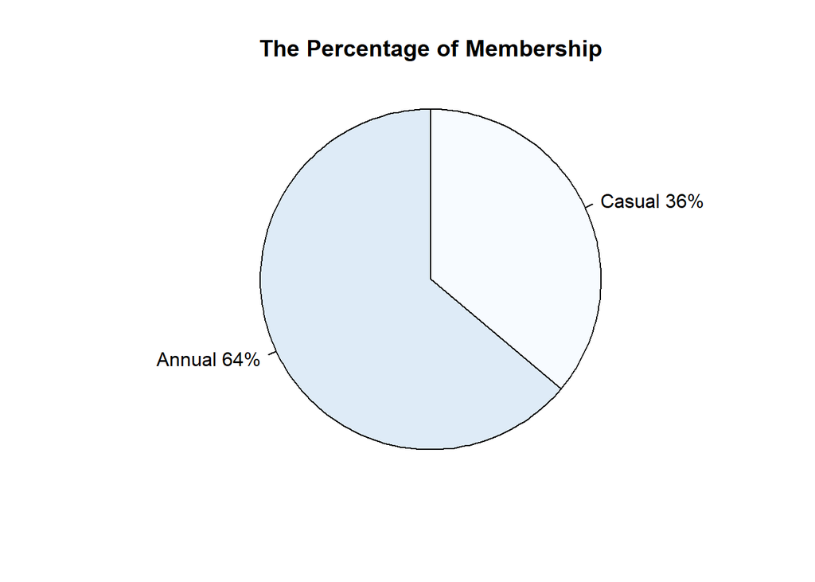

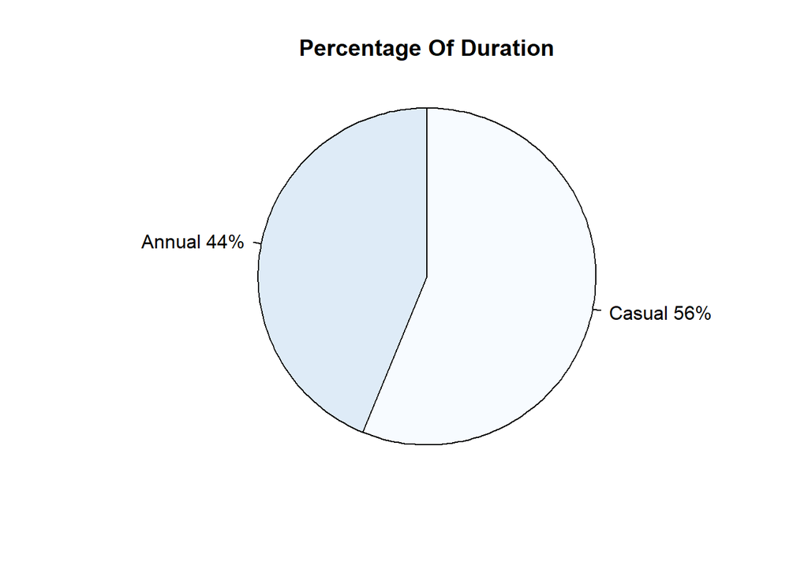

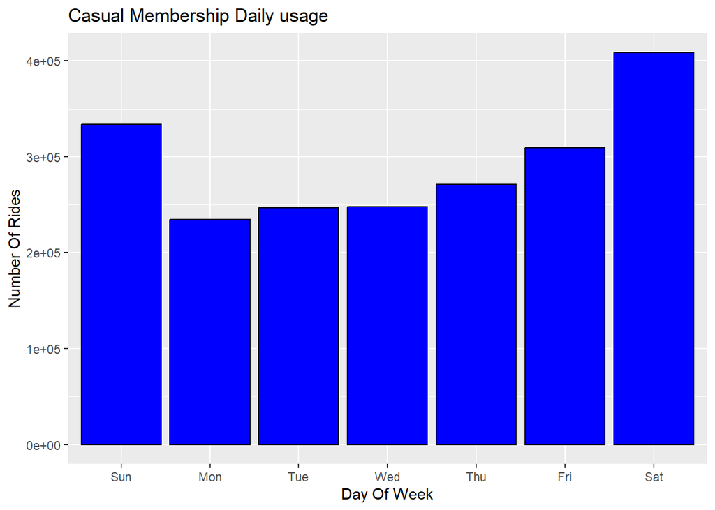

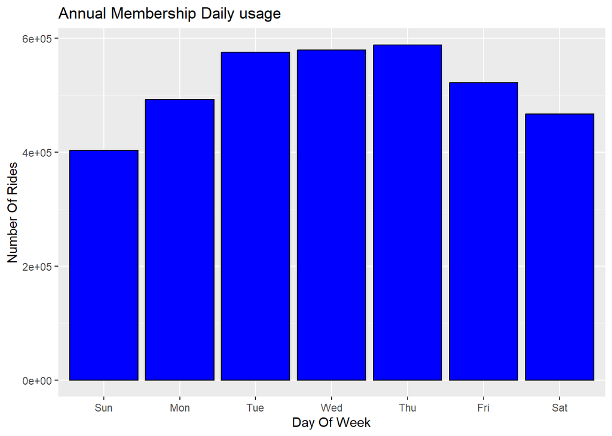

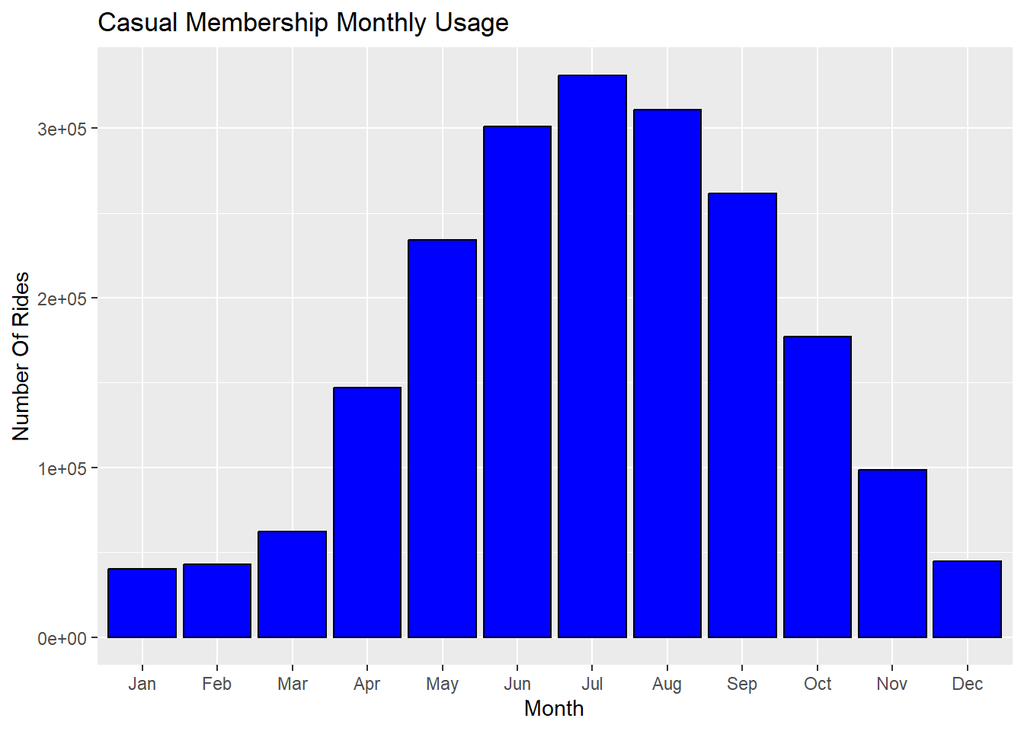

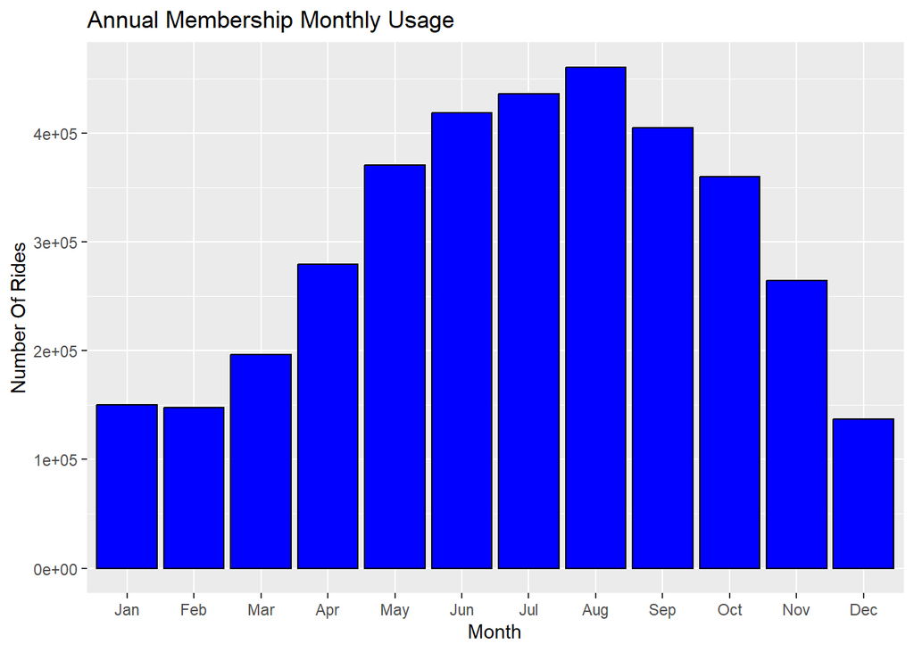

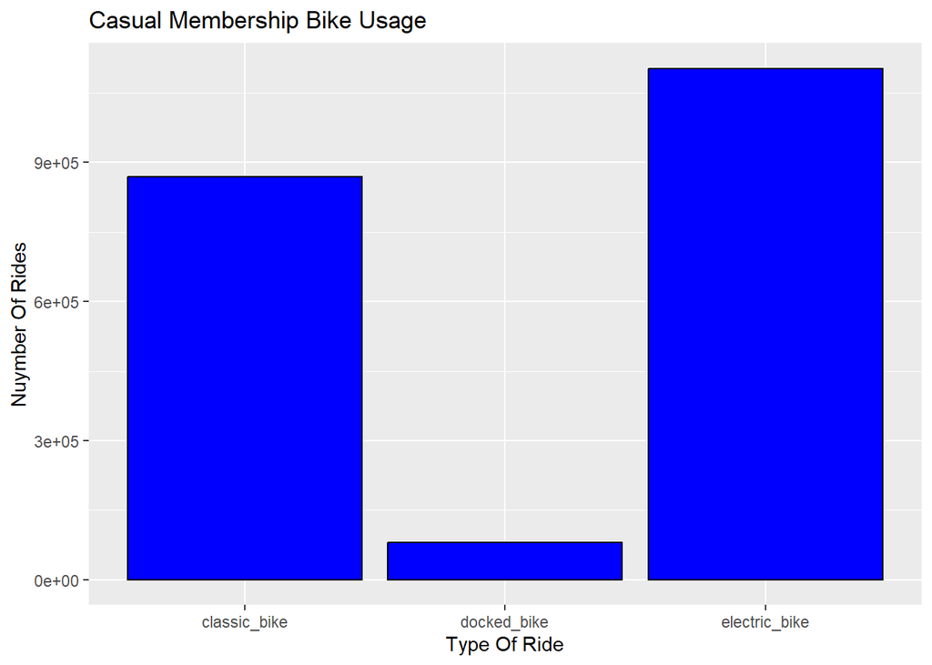

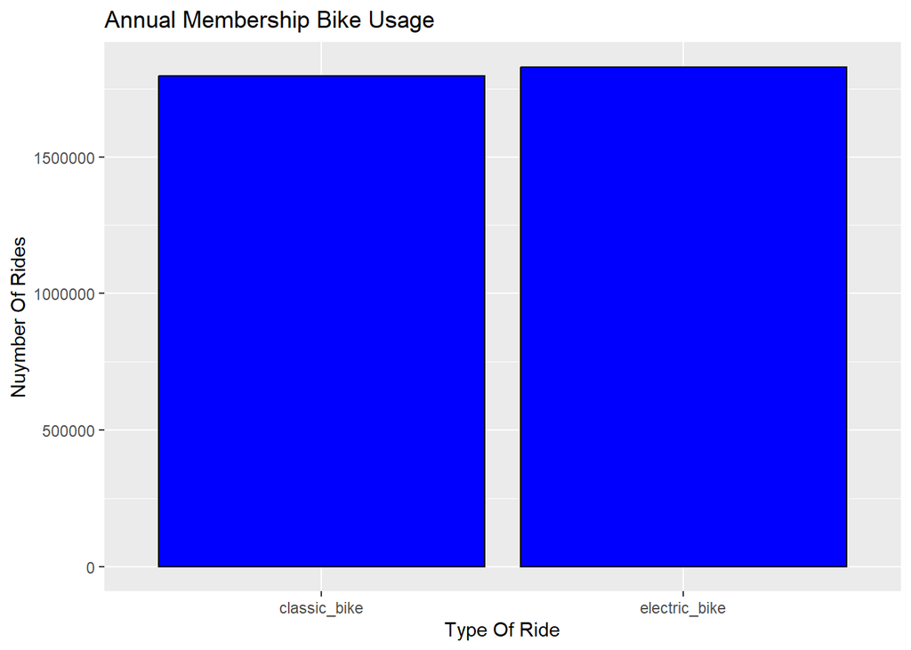